# Lab 14: Logistic regression

**Collaboration Policy**

Data science is a collaborative activity. While you may talk with others about the homework, we ask that you **write your solutions individually**. If you do discuss the assignments with others please **include their names** at the top of your solution.

## Due Date

This assignment is due at 11:59pm Sunday, December 8th.

In this lab you will practice logistic regression.

# Collaborators

Write names in this cell:

```python
# Run this cell to set up your notebook
import numpy as np
import pandas as pd
import sklearn
import sklearn.datasets
import sklearn.linear_model
import matplotlib.pyplot as plt
import seaborn as sns
import warnings
warnings.filterwarnings(category=FutureWarning, action='ignore')

import plotly.offline as py
import plotly.graph_objs as go
import plotly.figure_factory as ff


%matplotlib inline
sns.set()
sns.set_context("talk")
py.init_notebook_mode(connected=False)
```

In this lab we will be working on the breast cancer dataset. This dataset can be easily loaded using the `sklearn.datasets.load_breast_cancer()` method.  
The data format is not a `pandas.DataFrame` so we will create a new DataFrame from it.

```python
data = sklearn.datasets.load_breast_cancer()
# data is actually a dictionnary
print(data.keys())
print(data.DESCR)
```

```
dict_keys(['data', 'target', 'target_names', 'DESCR', 'feature_names', 'filename'])
.. _breast_cancer_dataset:

Breast cancer wisconsin (diagnostic) dataset
--------------------------------------------

**Data Set Characteristics:**

    :Number of Instances: 569

    :Number of Attributes: 30 numeric, predictive attributes and the class

    :Attribute Information:
        - radius (mean of distances from center to points on the perimeter)
        - texture (standard deviation of gray-scale values)
        - perimeter
        - area
        - smoothness (local variation in radius lengths)
        - compactness (perimeter^2 / area - 1.0)
        - concavity (severity of concave portions of the contour)
        - concave points (number of concave portions of the contour)
        - symmetry
        - fractal dimension ("coastline approximation" - 1)

        The mean, standard error, and "worst" or largest (mean of the three
        largest values) of these features were computed for each image,
        resulting in 30 features.  For instance, field 3 is Mean Radius, field
        13 is Radius SE, field 23 is Worst Radius.

        - class:
                - WDBC-Malignant
                - WDBC-Benign

    :Summary Statistics:

    ===================================== ====== ======
                                           Min    Max
    ===================================== ====== ======
    radius (mean):                        6.981  28.11
    texture (mean):                       9.71   39.28
```

[output cut: 64 more lines]

```
ftp ftp.cs.wisc.edu
cd math-prog/cpo-dataset/machine-learn/WDBC/

.. topic:: References

   - W.N. Street, W.H. Wolberg and O.L. Mangasarian. Nuclear feature extraction
     for breast tumor diagnosis. IS&T/SPIE 1993 International Symposium on
     Electronic Imaging: Science and Technology, volume 1905, pages 861-870,
     San Jose, CA, 1993.
   - O.L. Mangasarian, W.N. Street and W.H. Wolberg. Breast cancer diagnosis and
     prognosis via linear programming. Operations Research, 43(4), pages 570-577,
     July-August 1995.
   - W.H. Wolberg, W.N. Street, and O.L. Mangasarian. Machine learning techniques
     to diagnose breast cancer from fine-needle aspirates. Cancer Letters 77 (1994)
     163-171.
```

```python
df = pd.DataFrame(data.data, columns=data.feature_names)
df.head()
```

|  | mean radius | mean texture | mean perimeter | mean area | mean smoothness | mean compactness | mean concavity | mean concave points | mean symmetry | mean fractal dimension | ... | worst radius | worst texture | worst perimeter | worst area | worst smoothness | worst compactness | worst concavity | worst concave points | worst symmetry | worst fractal dimension |
| --- | --- | --- | --- | --- | --- | --- | --- | --- | --- | --- | --- | --- | --- | --- | --- | --- | --- | --- | --- | --- | --- |
| 0 | 17.99 | 10.38 | 122.80 | 1001.0 | 0.11840 | 0.27760 | 0.3001 | 0.14710 | 0.2419 | 0.07871 | ... | 25.38 | 17.33 | 184.60 | 2019.0 | 0.1622 | 0.6656 | 0.7119 | 0.2654 | 0.4601 | 0.11890 |
| 1 | 20.57 | 17.77 | 132.90 | 1326.0 | 0.08474 | 0.07864 | 0.0869 | 0.07017 | 0.1812 | 0.05667 | ... | 24.99 | 23.41 | 158.80 | 1956.0 | 0.1238 | 0.1866 | 0.2416 | 0.1860 | 0.2750 | 0.08902 |
| 2 | 19.69 | 21.25 | 130.00 | 1203.0 | 0.10960 | 0.15990 | 0.1974 | 0.12790 | 0.2069 | 0.05999 | ... | 23.57 | 25.53 | 152.50 | 1709.0 | 0.1444 | 0.4245 | 0.4504 | 0.2430 | 0.3613 | 0.08758 |
| 3 | 11.42 | 20.38 | 77.58 | 386.1 | 0.14250 | 0.28390 | 0.2414 | 0.10520 | 0.2597 | 0.09744 | ... | 14.91 | 26.50 | 98.87 | 567.7 | 0.2098 | 0.8663 | 0.6869 | 0.2575 | 0.6638 | 0.17300 |
| 4 | 20.29 | 14.34 | 135.10 | 1297.0 | 0.10030 | 0.13280 | 0.1980 | 0.10430 | 0.1809 | 0.05883 | ... | 22.54 | 16.67 | 152.20 | 1575.0 | 0.1374 | 0.2050 | 0.4000 | 0.1625 | 0.2364 | 0.07678 |

5 rows × 30 columns

Let us try to fit a simple model with only one feature.

```python
# Define our features/target
X = df[["mean radius"]]
# Target data['target'] = 0 is malignant 1 is benign
Y = (data.target == 0)
```

```python
# Split between train and test
from sklearn.model_selection import train_test_split
x_train, x_test,y_train,y_test = train_test_split(X,Y, test_size=0.25, random_state=42)

print(f"Training Data Size: {len(x_train)}")
print(f"Test Data Size: {len(x_test)}")
```

```
Training Data Size: 426
Test Data Size: 143
```

### Question 1

Now let us first fit a logistic regression model using the training set.  
We will compute the training and testing accuracy, defined as:

$$ \large \text{Training Accuracy} = \frac{1}{n_{train\_set}} \sum_{i \in \text{train_set}} {\mathbb{1}_{y_i == \hat{y_i}}} $$$$ \large \text{Testing Accuracy} = \frac{1}{n_{test\_set}} \sum_{i \in \text{test_set}} {\mathbb{1}_{y_i == \hat{y_i}}} $$

where $ y_i $ is the prediction of our model, $ y_i $ the ground truth and $\mathbb{1}_{y_i == \hat{y_i}}$ an indicator function ($ \mathbb{1}_{y_i == \hat{y_i}} = 1 \iff y_i = \hat{y_i}$).

```
BEGIN QUESTION
name: q1
```

```python
lr = sklearn.linear_model.LogisticRegression(fit_intercept=True) #, solver='sag', max_iter=1000)
lr.fit(x_train,y_train)
lr.fit(x_test,y_test)

# YOUR CODE HERE
train_accuracy = sum(lr.predict(x_train) == y_train)/len(x_train)
test_accuracy = sum(lr.predict(x_test) == y_test)/len(x_test)

# raise NotImplementedError()

print(f"Train accuracy: {train_accuracy:.4f}")
print(f"Test accuracy: {test_accuracy:.4f}")
```

```
Train accuracy: 0.8709
Test accuracy: 0.9161
```

```python
# TEST
assert sum(lr.predict(x_test) == y_test) == 131
```

### Question 2

It seems we can a get very high test accuracy. Then how about precision and recall?

- Precision (also called positive predictive value) is the fraction of relevant instances among the retrieved instances.
- Recall is the fraction of relevant instances that have been retrieved over the total amount of relevant instances.

Precision is the ability of the classifier not to label as positive a sample that is negative while recall is the ability of the classifier to find all the positive samples.

```
Confusion matrix, without normalization
[[89  0]
 [12 42]]
Normalized confusion matrix
[[1.         0.        ]
 [0.22222222 0.77777778]]
```

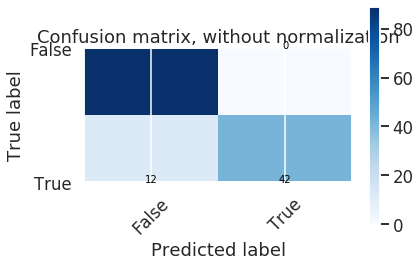

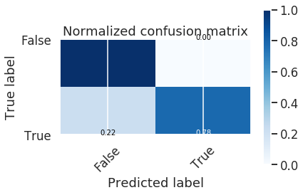

```python
from sklearn.metrics import confusion_matrix

cnf_matrix = confusion_matrix(y_test, lr.predict(x_test))

def plot_confusion_matrix(cm, classes,
                          normalize=False,
                          title='Confusion matrix',
                          cmap=plt.cm.Blues):
    """
    This function prints and plots the confusion matrix.
    Normalization can be applied by setting `normalize=True`.
    """
    import itertools
    if normalize:
        cm = cm.astype('float') / cm.sum(axis=1)[:, np.newaxis]
        print("Normalized confusion matrix")
    else:
        print('Confusion matrix, without normalization')

    print(cm)

    plt.imshow(cm, interpolation='nearest', cmap=cmap)
    plt.title(title)
    plt.colorbar()
    tick_marks = np.arange(len(classes))
    plt.xticks(tick_marks, classes, rotation=45)
    plt.yticks(tick_marks, classes)

    fmt = '.2f' if normalize else 'd'
    thresh = cm.max() / 2.
    for i, j in itertools.product(range(cm.shape[0]), range(cm.shape[1])):
        plt.text(j, i, format(cm[i, j], fmt),
                 horizontalalignment="center",
                 color="white" if cm[i, j] > thresh else "black")

#     plt.tight_layout()
    plt.ylabel('True label')
    plt.xlabel('Predicted label')

class_names = ['False', 'True']
# Plot non-normalized confusion matrix
plt.figure()
plot_confusion_matrix(cnf_matrix, classes=class_names,
                      title='Confusion matrix, without normalization')

# Plot normalized confusion matrix
plt.figure()
plot_confusion_matrix(cnf_matrix, classes=class_names, normalize=True,
                      title='Normalized confusion matrix')
```

Then: $$ \text{Precision} = \frac{n_{true\_positives}}{n_{true\_positives} + n_{false\_positives}} $$

$$ \text{Recall} = \frac{n_{true\_positives}}{n_{true\_positives} + n_{false\_negatives}} $$

As illustrated in the figure below:

[figure not shown]

Now let's compute the precision and recall for the test set using the model we got from question 1.  
Please do not use the `sklearn.metrics` for this computation.

```
BEGIN QUESTION
name: q2
```

```python
lr.fit(x_train,y_train)
y_pred = lr.predict(x_test)
# YOUR CODE HERE
precision = sum((y_pred == y_test) & (y_test == True)) / sum(y_pred)
recall = sum((y_pred == y_test) & (y_test == True)) / sum(y_test)


# raise NotImplementedError()
print(f'precision = {precision:.4f}')
print(f'recall = {recall:.4f}')
```

```
precision = 0.9773
recall = 0.7963
```

```python
# TEST
assert np.isclose(precision, 0.97727272727272729) == True
```

What can you infer from these results? Please consider the following plots, that display the distribution of the target variable in the training and testing sets.

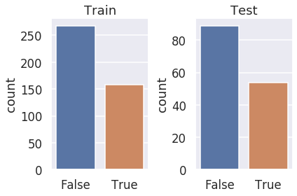

```python
fig, axes = plt.subplots(1, 2)
sns.countplot(y_train, ax=axes[0]);
sns.countplot(y_test, ax=axes[1]);

axes[0].set_title('Train')
axes[1].set_title('Test')
plt.tight_layout();
```

**SOLUTION: Given the following plots that display the distribution of the target variable in the training and testing sets, what can be inferred from the results is that for the training and testing set, there is a higher count of Falses in contrast to a lower number of Trues. This means that there is a high distribution of the target variable, which could, for example, be the indication of breast cancer. So, for the Training set, based solely on the chart, there is about 264 False results and 162 True results. As for the testing data, again, only based on the graph, there are about 90 False results, and 53 True results. Given that the accuracy and precision are high, and the recall is somewhat high for the test set, this gives context as to why there are so many True results, since the classifier can determine whether a patient has cancer or not, or whatever the target variable measures or represents. This means that the fraction of relevant instances among the retrieved instances is high, and the the fraction of relevant instances that have been retrieved over the total amount of relevant instances is somewhat high as well. Another observation is that the train and test sets seem to have the same proportion of False to True.**

### Question 3

Now let's try to analyze the cross entropy loss. Recall that loss would be: $$\Large L(\theta) = -\frac{1}{n} \sum_{i=1}^n y_i \log \left(\sigma\left(\phi(x_i)^T \theta\right) \right) + (1-y_i) \log \left(1 - \sigma\left(\phi(x_i)^T \theta\right) \right) $$

```python
theta = np.array([lr.coef_[0][0],
                  lr.intercept_[0]])
Phi = np.hstack([X,
                 np.ones([len(X), 1])])
print(theta)
print()
print(Phi)
```

```
[ 0.47565755 -7.22821319]

[[17.99  1.  ]
 [20.57  1.  ]
 [19.69  1.  ]
 ...
 [16.6   1.  ]
 [20.6   1.  ]
 [ 7.76  1.  ]]
```

```
BEGIN QUESTION
name: q3
```

```python
def lr_loss(theta, Phi, Y):
    '''
    Compute the cross entropy loss using Phi, Y and theta. Hint: # The notation B @ v means:
    compute the matrix multiplication Bv

    Args:
        theta: The model parameters.
        Phi: The transformed input data \phi(X)
        Y: The label

    Return:
        The cross entropy loss.
    '''
    # YOUR CODE HERE
    loss = Y * np.log(1 / (1 + np.exp(Phi @ theta))) + (1 - Y) * np.log(1 - 1 / (1 + np.exp(Phi @ theta)))

#     raise NotImplementedError()
    return -np.mean(loss)
```

```python
# TEST
assert np.isclose(lr_loss(np.array([0, 0]), Phi, Y), 0.69314718055994529) == True
```

```python
uvalues = np.linspace(-8,8,70)
vvalues = np.linspace(-5,5,70)
(u,v) = np.meshgrid(uvalues, vvalues)
thetas = np.vstack((u.flatten(),v.flatten()))
lr_loss_values = np.array([lr_loss(t, Phi, Y) for t in thetas.T])
lr_loss_surface = go.Surface(name="Logistic Regression Loss",
        x=u, y=v, z=np.reshape(lr_loss_values,(len(uvalues), len(vvalues))),
        contours=dict(z=dict(show=True, color="gray", project=dict(z=True)))
    )

py.iplot(go.Figure(data=[lr_loss_surface]))
```

[interactive chart not shown]

What remarks can you make on this plot?

#### SOLUTION HERE:

Assuming this graph shows the cross-entropy loss or logistic loss, some remarks that can be made about this plot are that: this 3-D plot shows a downward, check-mark trend that transcends a bright red to white, to light blue to dark blue. The trend also descends to zero, then immediately bends up from its minimum theta (X) value, meaning that the graph is convex. This might be because when we use the cross-entropy loss, which means that we use the sigmoid function.

We avoid using the square loss (linear model with Ridge regression, L2 regularization norm) because it does not result in a convex graph even though it shrinks the weights to increase bias, and reduces the variance.